# Europese vlinderindex (graslanden)

Stijn Van Hoey

September 13, 2016

## Evolutie van de afzonderlijke soorten

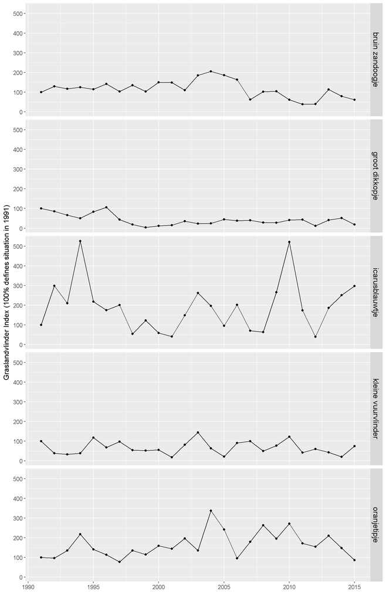

## Evolutie van Argusvlinder en Hooibeestje

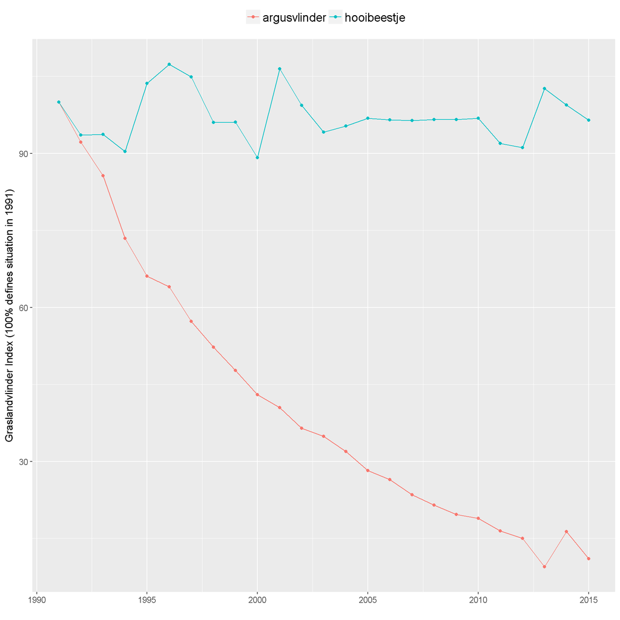

## Evolutie van de vlinderindex graslanden

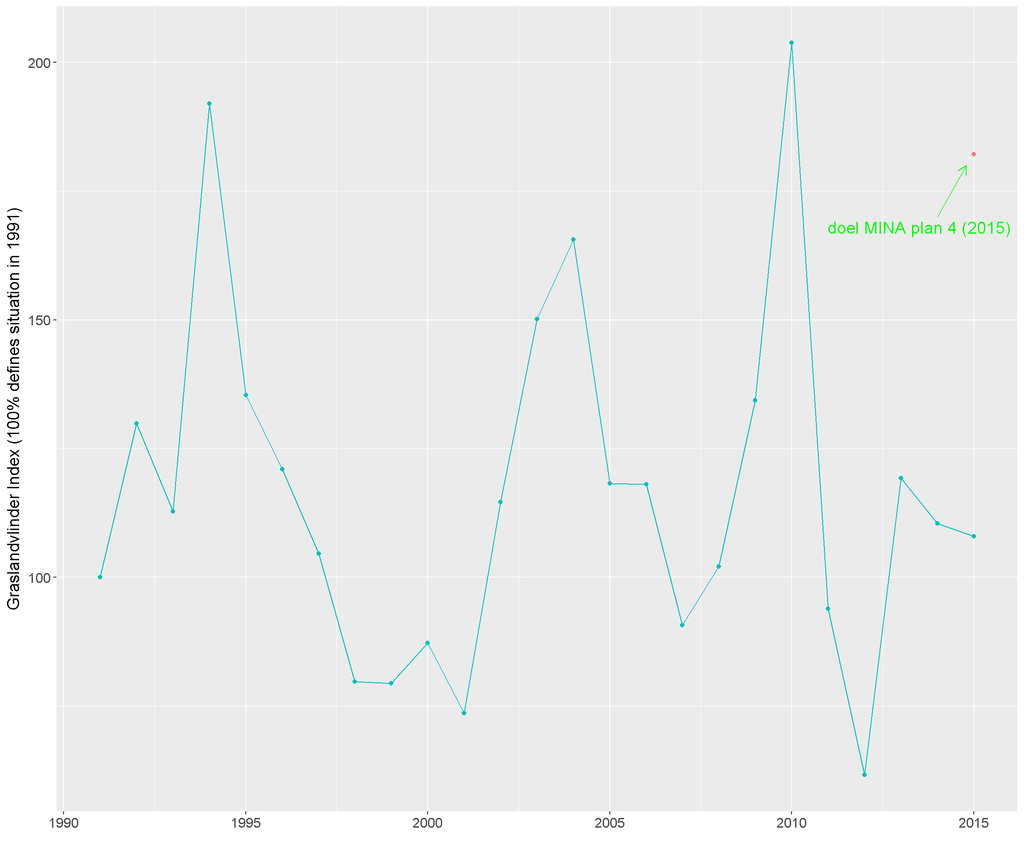

## Bespreking

De Vlaamse graslandvlinderindex vertoont een wisselend verloop. De samengestelde indicator daalt licht gedurende de eerste 10 jaar van de monitoring maar schommelt sindsdien sterk. Twee soorten dalen beduidend (bruin zandoogje en groot dikkopje), twee soorten blijven stabiel (icarusblauwtje en kleine vuurvlinder) en een soort (oranjetipje) neemt beduidend toe. Voor de overige twee soorten (argusvlinder en hooibeestje) zijn er relatief weinig vlinderroutes. Het hooibeestje lijkt min of meer stabiel te blijven, maar de argusvlinder toont een bijzonder sterke achteruitgang (Van Dyck et al. 2015).

## Beleidsdoelen

- Streefdoel 2 EU 2020 biodiversiteitsstrategie:Tegen 2020 worden ecosystemen en ecosysteemdiensten gehandhaafd en verbeterd door groene infrastructuur op te zetten en ten minste 15 % van de aangetaste ecosystemen te herstellen.
- Plandoelstelling MINA-plan 4: In 2015 is de toestand van bedreigde en beschermde soortengroepen verbeterd: + 10% t.o.v. 2004.
- PACT2020 15.1 Inzake biodiversiteit kan Vlaanderen in 2020 de vergelijking met de Europese economische topregio’s aan.
- SEBI 01 Abundance and distribution of selected species